# hw4_morning

載入套件

```r
library(dplyr)
```

```r
library(ggplot2)
```

讀檔，重整並合併資料

```r
train <- read.csv("./all/train.csv", stringsAsFactors=FALSE)
test  <- read.csv("./all/test.csv",  stringsAsFactors=FALSE)
gender_submission  <- read.csv("./all/gender_submission.csv",  stringsAsFactors=FALSE)

full_test <- merge(test, gender_submission ,by= "PassengerId", all = T)
all <- bind_rows(train, full_test)

head(all)
```

```
##   PassengerId Survived Pclass
## 1           1        0      3
## 2           2        1      1
## 3           3        1      3
## 4           4        1      1
## 5           5        0      3
## 6           6        0      3
##                                                  Name    Sex Age SibSp
## 1                             Braund, Mr. Owen Harris   male  22     1
## 2 Cumings, Mrs. John Bradley (Florence Briggs Thayer) female  38     1
## 3                              Heikkinen, Miss. Laina female  26     0
## 4        Futrelle, Mrs. Jacques Heath (Lily May Peel) female  35     1
## 5                            Allen, Mr. William Henry   male  35     0
## 6                                    Moran, Mr. James   male  NA     0
##   Parch           Ticket    Fare Cabin Embarked
## 1     0        A/5 21171  7.2500              S
## 2     0         PC 17599 71.2833   C85        C
## 3     0 STON/O2. 3101282  7.9250              S
## 4     0           113803 53.1000  C123        S
## 5     0           373450  8.0500              S
## 6     0           330877  8.4583              Q
```

```r
tail(all)
```

```
##      PassengerId Survived Pclass                           Name    Sex
## 1304        1304        1      3 Henriksson, Miss. Jenny Lovisa female
## 1305        1305        0      3             Spector, Mr. Woolf   male
## 1306        1306        1      1   Oliva y Ocana, Dona. Fermina female
## 1307        1307        0      3   Saether, Mr. Simon Sivertsen   male
## 1308        1308        0      3            Ware, Mr. Frederick   male
## 1309        1309        0      3       Peter, Master. Michael J   male
##       Age SibSp Parch             Ticket     Fare Cabin Embarked
## 1304 28.0     0     0             347086   7.7750              S
## 1305   NA     0     0          A.5. 3236   8.0500              S
## 1306 39.0     0     0           PC 17758 108.9000  C105        C
## 1307 38.5     0     0 SOTON/O.Q. 3101262   7.2500              S
## 1308   NA     0     0             359309   8.0500              S
## 1309   NA     1     1               2668  22.3583              C
```

# Part.A

檢驗存活度與票價之間的關聯

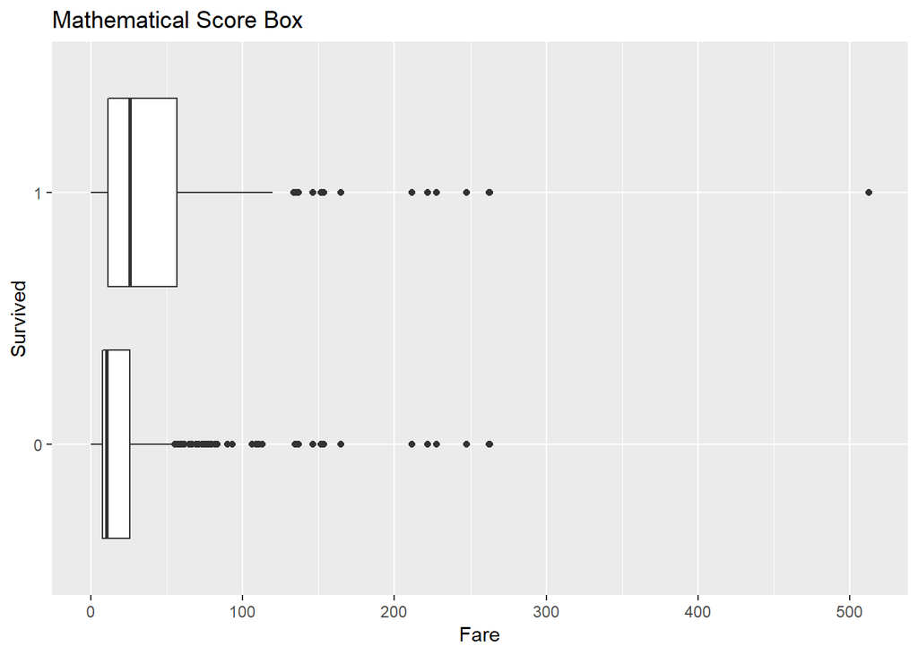

```r
all$Survived <- as.factor(all$Survived)
ggplot(data = all, aes(x = Survived, y = Fare)) +
 geom_boxplot() + coord_flip() +
 labs( y = 'Fare', x = 'Survived',
       title = 'Mathematical Score Box')
```

*從BoxPlot可以看出，購買票價的乘客存活人數更多。

計算信賴區間

```r
all <- na.omit(all)

with(all,
     tapply(Fare , Survived,
     function(x)
       c(mean(x) + c(-2, 2) * sd(x)/sqrt(length(x)))))
```

```
## $`0`
## [1] 22.86160 28.73623
##
## $`1`
## [1] 45.94848 60.21571
```

```r
t.test(Fare ~ Survived, data = all)
```

```
##
##  Welch Two Sample t-test
##
## data:  Fare by Survived
## t = -7.0731, df = 558.37, p-value = 4.555e-12
## alternative hypothesis: true difference in means is not equal to 0
## 95 percent confidence interval:
##  -34.85985 -19.70651
## sample estimates:
## mean in group 0 mean in group 1
##        25.79892        53.08210
```

```r
t.test(Fare ~ Survived, data = all, var.equal = TRUE)
```

```
##
##  Two Sample t-test
##
## data:  Fare by Survived
## t = -7.9787, df = 1043, p-value = 3.873e-15
## alternative hypothesis: true difference in means is not equal to 0
## 95 percent confidence interval:
##  -33.99306 -20.57330
## sample estimates:
## mean in group 0 mean in group 1
##        25.79892        53.08210
```

# 小結：以票價來說，購買越高價位的人存活度更高，

# Part.B

以下觀察上船地點是否與票價有關

```r
library(Hmisc)
all$Embarked <- as.factor(all$Embarked)
tapply(all$Fare, all$Embarked, mean)
```

```
##                 C        Q        S
## 80.00000 72.47416 15.90592 28.19096
```

去掉資料中的NA

```r
all <- na.omit(all)
```

[figure not shown]

```r
ggplot(data = all,
       aes(x = Embarked, y = Fare)) +
  stat_summary(fun.data = 'mean_cl_boot', size = 1) +
  scale_y_continuous(breaks = seq(500, 660, by = 20)) +
  geom_hline(yintercept = mean(all$Fare) ,
             linetype = 'dotted') +
  labs(x = '上船地點', y ='票價') +
  coord_flip()
```

推測社經地位與上船地點有關，畫圖觀察看看。

```r
anova(m1 <- lm(Fare ~ Pclass, data = all))
```

```
## Analysis of Variance Table
##
## Response: Fare
##             Df  Sum Sq Mean Sq F value    Pr(>F)
## Pclass       1 1036114 1036114  489.73 < 2.2e-16 ***
## Residuals 1043 2206670    2116
## ---
## Signif. codes:  0 '***' 0.001 '**' 0.01 '*' 0.05 '.' 0.1 ' ' 1
```

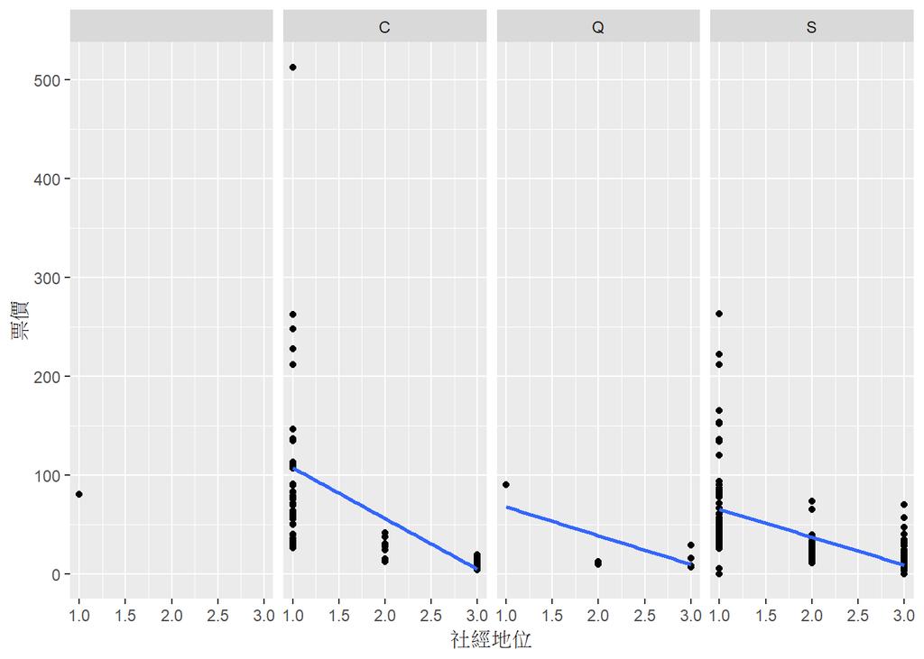

```r
ggplot(data = all,
       aes(group = Pclass,
          y = Fare, x = Pclass)) +
  geom_point() +
  stat_smooth(method = 'lm', se = F) +
  stat_smooth(aes(group = Embarked,
          y = Fare, x = Pclass),
          method = 'lm', se = F) +
  facet_grid( . ~  Embarked) +
  labs(x = '社經地位', y = '票價')
```

利用以下 ANOVA 檢驗假設是否正確

```r
anova(m2 <- update(m1, . ~ . +
            Embarked, data = all))
```

```
## Analysis of Variance Table
##
## Response: Fare
##             Df  Sum Sq Mean Sq F value    Pr(>F)
## Pclass       1 1036114 1036114 505.912 < 2.2e-16 ***
## Embarked     3   76736   25579  12.489 5.006e-08 ***
## Residuals 1040 2129934    2048
## ---
## Signif. codes:  0 '***' 0.001 '**' 0.01 '*' 0.05 '.' 0.1 ' ' 1
```

```r
anova(m3 <- update(m2, . ~ . - Pclass,  data = all))
```

```
## Analysis of Variance Table
##
## Response: Fare
##             Df  Sum Sq Mean Sq F value    Pr(>F)
## Embarked     3  353232  117744  42.419 < 2.2e-16 ***
## Residuals 1041 2889552    2776
## ---
## Signif. codes:  0 '***' 0.001 '**' 0.01 '*' 0.05 '.' 0.1 ' ' 1
```

將 ANOVA 結果做成圖表輸出，先計算一些需要的數據

```r
res_lm <- lapply(list(m1, m2, m3), summary)
(res_lm[[2]]$r.sq - res_lm[[3]]$r.sq)/res_lm[[2]]$r.sq
```

```
## [1] 0.6825877
```

```r
anova(m3, m2)
```

```
## Analysis of Variance Table
##
## Model 1: Fare ~ Embarked
## Model 2: Fare ~ Pclass + Embarked
##   Res.Df     RSS Df Sum of Sq     F    Pr(>F)
## 1   1041 2889552
## 2   1040 2129934  1    759618 370.9 < 2.2e-16 ***
## ---
## Signif. codes:  0 '***' 0.001 '**' 0.01 '*' 0.05 '.' 0.1 ' ' 1
```

```r
(res_lm[[2]]$r.sq - res_lm[[1]]$r.sq)/res_lm[[1]]$r.sq
```

```
## [1] 0.07406137
```

```r
anova(m1, m2)
```

```
## Analysis of Variance Table
##
## Model 1: Fare ~ Pclass
## Model 2: Fare ~ Pclass + Embarked
##   Res.Df     RSS Df Sum of Sq      F    Pr(>F)
## 1   1043 2206670
## 2   1040 2129934  3     76736 12.489 5.006e-08 ***
## ---
## Signif. codes:  0 '***' 0.001 '**' 0.01 '*' 0.05 '.' 0.1 ' ' 1
```

畫圖

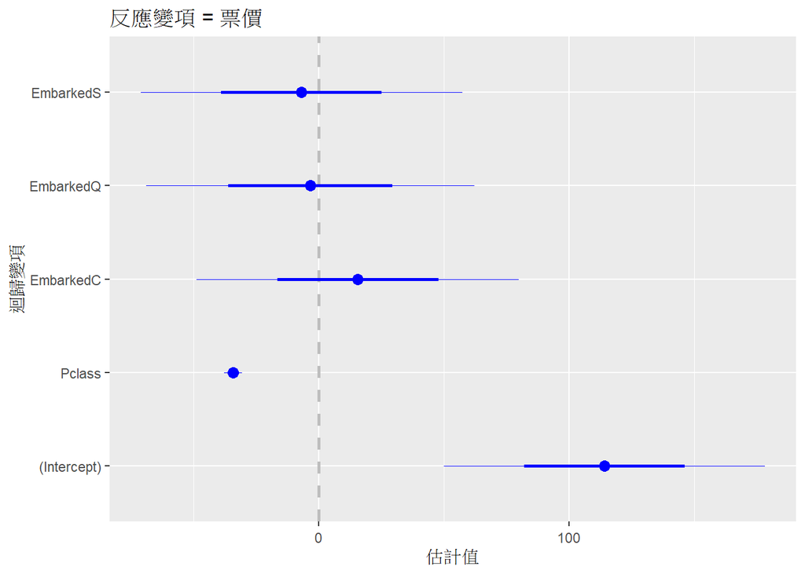

```r
library(coefplot)
m2 <- lm(Fare ~ Pclass + Embarked,
         data = all)
coefplot(m2, xlab = '估計值', ylab = '迴歸變項', title = '反應變項 = 票價')
```

把資料與迴歸分析的預測值、殘差與影響度放進資料

```r
fit_m2 <- data.frame(all[, c(3, 10, 12)], fitted = fitted(m2), resid = resid(m2),
                     infl = influence(m2)$hat )
```

殘差分配，依上船地點，檢視常態與變異數同質假設

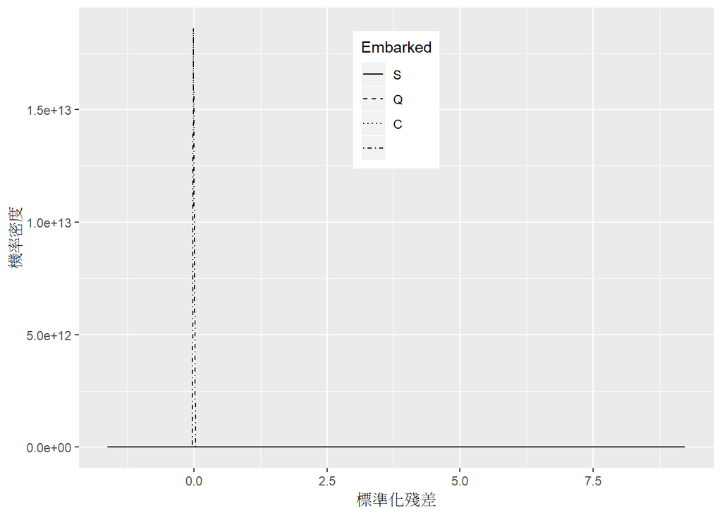

```r
ggplot(data = fit_m2, aes(x = scale(resid)), group = Embarked ) +
 stat_density(geom = 'path', position = 'identity', aes(linetype = Embarked)) +
 scale_linetype_manual(values = 4:1) +
 guides(linetype = guide_legend(reverse = TRUE)) +
 labs(x = '標準化殘差', y = '機率密度') +
 theme(legend.position = c(.50, .8))
```

看看殘差的 Q-Q 圖，依上船地點。檢視常態假設

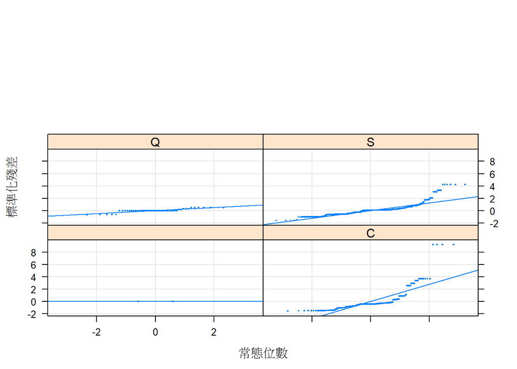

```r
library(lattice)
qqmath(~ scale(resid) | Embarked, data = fit_m2, type = c('p', 'g', 'r'),
       xlab = '常態位數', ylab = '標準化殘差', layout = c(2, 3),
       pch = '.', cex = 2)
```

畫預測值與殘差的散佈圖，檢查線性與等分散假設

```r
library(MASS)
```

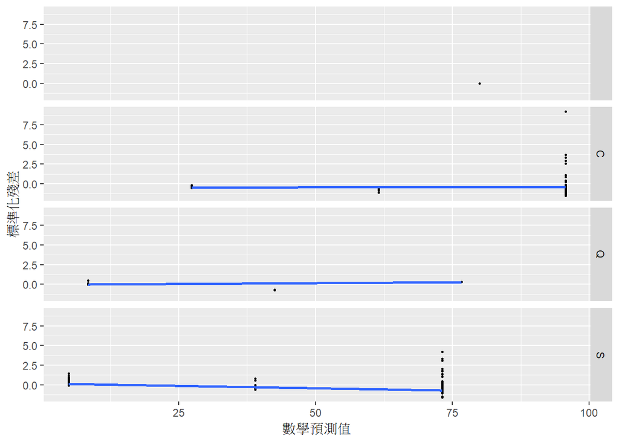

```r
library(ggplot2)
ggplot(data = fit_m2, aes(x = fitted, y = scale(resid), group = Embarked )) +
  geom_point(pch = 20, size = 1) +
  stat_smooth(method = 'rlm', se = F) +
  facet_grid(Embarked ~ .) +
  labs(x = '數學預測值', y = '標準化殘差')
```

呈現影響值（影響估計結果過大的值）與標準化殘差

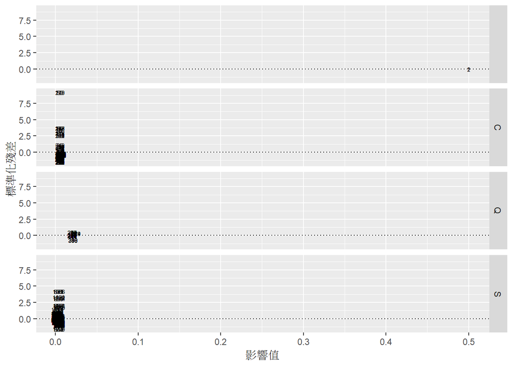

```r
ggplot(data = fit_m2, aes(x = infl, y = scale(resid), group = Embarked)) +
 geom_text(aes(label = rownames(fit_m2)), cex = 2) +
 geom_hline(yintercept = 0, linetype = 'dotted') +
 facet_grid(Embarked ~ .) +
 labs(x = '影響值', y = '標準化殘差')
```

看看影響值

```r
summary(influence(m2)$hat)
```

```
##     Min.  1st Qu.   Median     Mean  3rd Qu.     Max.
## 0.001434 0.001998 0.001998 0.004785 0.004875 0.500000
```

分析資料其他變項是否和票價有關

```r
a <- sub("male","0",all$Sex)
b <- sub("fe0","1",a)
all$Sex <- as.numeric(b)
all$SibSp <- as.numeric(all$SibSp)
all$Parch <- as.numeric(all$Parch)
all_Fare <- all[, c('Fare', 'Sex',
                    'Age', 'SibSp', 'Parch')]
```

基本統計量

```r
colMeans(all_Fare)
```

```
##       Fare        Sex        Age      SibSp      Parch
## 36.6860803  0.3712919 29.8518373  0.5033493  0.4210526
```

呈現兩兩散佈圖

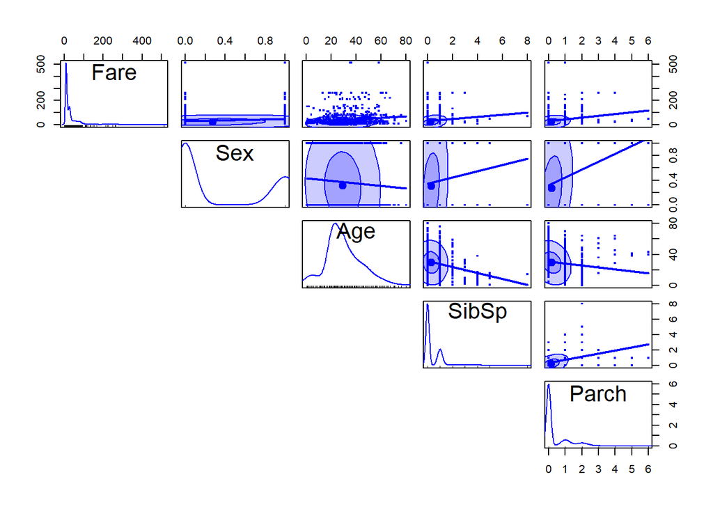

```r
library(heplots)
scatterplotMatrix(~ Fare + Sex + Age + SibSp + Parch, data= all_Fare,
  pch = '.', cex = 3, smooth = FALSE, ellipse = TRUE,
  diagonal = 'none', lower.panel = NULL)
```

利用corrplot 套件，以圖形顯示相關性的大小

[figure not shown]

```r
library(corrplot)
corrplot(cor(all_Fare), method = 'ellipse', order = 'hclust', addrect = 4,
         type = 'upper', tl.pos = 'tp')
corrplot(cor(all_Fare), add = TRUE, type = 'lower', method = 'number',
         order = 'hclust', col = 'black', diag = FALSE, tl.pos = 'n', cl.pos = 'n')
```

放進四個解釋變項

```r
summary(m4 <- lm(Fare ~ + Sex + Age + SibSp + Parch, data= all_Fare))
```

```
##
## Call:
## lm(formula = Fare ~ +Sex + Age + SibSp + Parch, data = all_Fare)
##
## Residuals:
##    Min     1Q Median     3Q    Max
## -91.74 -22.74 -10.25   0.68 485.92
##
## Coefficients:
##             Estimate Std. Error t value Pr(>|t|)
## (Intercept)  -6.6397     4.3462  -1.528 0.126886
## Sex          17.6567     3.4264   5.153 3.06e-07 ***
## Age           0.9443     0.1160   8.142 1.10e-15 ***
## SibSp         7.3701     1.9491   3.781 0.000165 ***
## Parch        11.5681     2.1194   5.458 6.01e-08 ***
## ---
## Signif. codes:  0 '***' 0.001 '**' 0.01 '*' 0.05 '.' 0.1 ' ' 1
##
## Residual standard error: 52.17 on 1040 degrees of freedom
## Multiple R-squared:  0.1272, Adjusted R-squared:  0.1238
## F-statistic: 37.89 on 4 and 1040 DF,  p-value: < 2.2e-16
```

結果

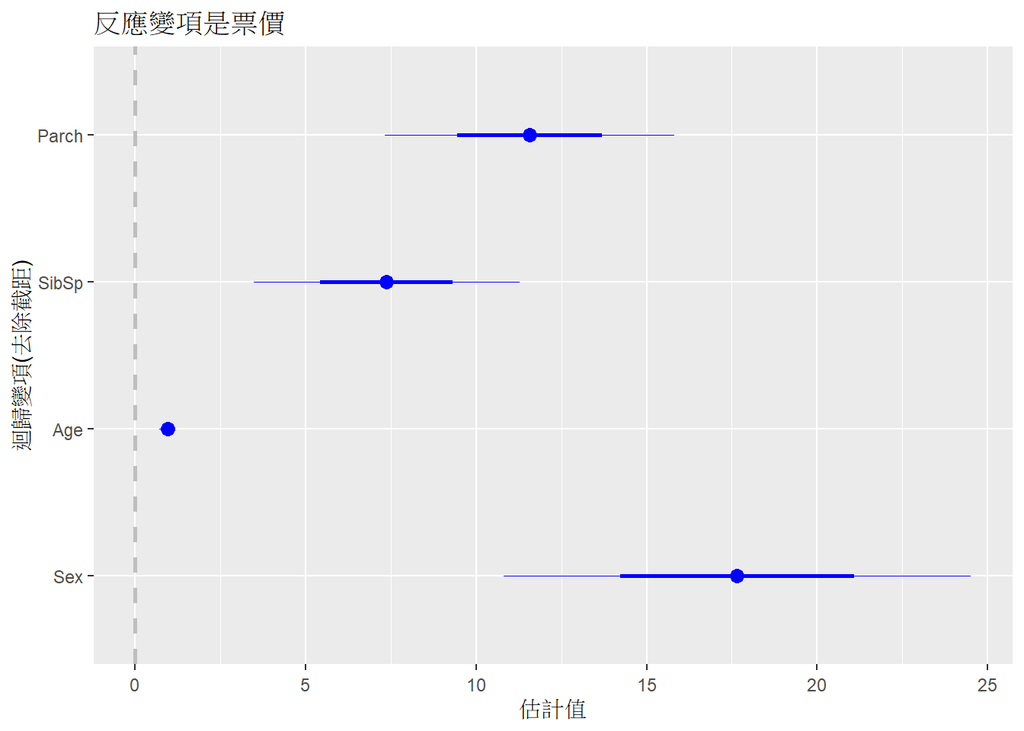

```r
coefplot(m4, predictors = c('Sex',
                    'Age', 'SibSp', 'Parch'),
 xlab = '估計值', ylab = '迴歸變項(去除截距)', title = '反應變項是票價')
```

```r
library(effects)
```

[figure not shown]

```r
plot(allEffects(m4), main = '', ylim = c(550, 670), grid = T)
```

利用 lm.beta 套件，計算標準化迴歸係數

```r
library(lm.beta)
summary(lm.beta(m4))
```

```
##
## Call:
## lm(formula = Fare ~ +Sex + Age + SibSp + Parch, data = all_Fare)
##
## Residuals:
##    Min     1Q Median     3Q    Max
## -91.74 -22.74 -10.25   0.68 485.92
##
## Coefficients:
##             Estimate Standardized Std. Error t value Pr(>|t|)
## (Intercept)  -6.6397       0.0000     4.3462  -1.528 0.126886
## Sex          17.6567       0.1531     3.4264   5.153 3.06e-07 ***
## Age           0.9443       0.2438     0.1160   8.142 1.10e-15 ***
## SibSp         7.3701       0.1207     1.9491   3.781 0.000165 ***
## Parch        11.5681       0.1744     2.1194   5.458 6.01e-08 ***
## ---
## Signif. codes:  0 '***' 0.001 '**' 0.01 '*' 0.05 '.' 0.1 ' ' 1
##
## Residual standard error: 52.17 on 1040 degrees of freedom
## Multiple R-squared:  0.1272, Adjusted R-squared:  0.1238
## F-statistic: 37.89 on 4 and 1040 DF,  p-value: < 2.2e-16
```

看看控制Sex、SibSp、Parch後，看看Age的效果

```r
summary(m5 <- update(m4, . ~ . - Age , data = all_Fare))
```

```
##
## Call:
## lm(formula = Fare ~ Sex + SibSp + Parch, data = all_Fare)
##
## Residuals:
##    Min     1Q Median     3Q    Max
## -70.65 -24.08 -15.84   2.39 488.44
##
## Coefficients:
##             Estimate Std. Error t value Pr(>|t|)
## (Intercept)   23.894      2.265  10.550  < 2e-16 ***
## Sex           16.877      3.531   4.780 2.01e-06 ***
## SibSp          4.139      1.967   2.104   0.0356 *
## Parch         10.551      2.181   4.837 1.51e-06 ***
## ---
## Signif. codes:  0 '***' 0.001 '**' 0.01 '*' 0.05 '.' 0.1 ' ' 1
##
## Residual standard error: 53.78 on 1041 degrees of freedom
## Multiple R-squared:  0.07154,    Adjusted R-squared:  0.06887
## F-statistic: 26.74 on 3 and 1041 DF,  p-value: < 2.2e-16
```

```r
anova(m5, m4)
```

```
## Analysis of Variance Table
##
## Model 1: Fare ~ Sex + SibSp + Parch
## Model 2: Fare ~ +Sex + Age + SibSp + Parch
##   Res.Df     RSS Df Sum of Sq      F    Pr(>F)
## 1   1041 3010791
## 2   1040 2830359  1    180433 66.299 1.101e-15 ***
## ---
## Signif. codes:  0 '***' 0.001 '**' 0.01 '*' 0.05 '.' 0.1 ' ' 1
```